# simulation_results on simulated Spipoll

### Simulation 8

- 6 covariables ont un effet qui dépend d’un groupe (positif/négatif/nul)
- 6 covariables sans effet
- 4 groupes avec des effets différents

```
## [1] "AUC sessions-insectes sans covariables : 0.838"
```

```
## [1] "AUC sessions-insectes avec covariables : 0.837"
```

```
## [1] "AUC plantes-insectes sans covariables : 0.657"
```

```
## [1] "AUC plantes-insectes avec covariables : 0.668"
```

|  | Shapley | GRAD | GRADxInput | IG | GRAD_LM | IG1_LM |
| --- | --- | --- | --- | --- | --- | --- |
| + | 0.54 | 0.80 | 0.79 | 0.82 | 0.80 | 0.82 |
| - | 0.53 | 0.53 | 0.10 | 0.10 | 0.10 | 0.52 |
| AUC | 0.53 | 0.37 | 0.83 | 0.85 | 0.89 | 0.40 |

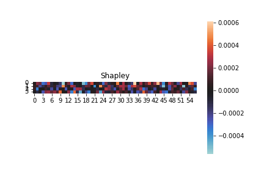

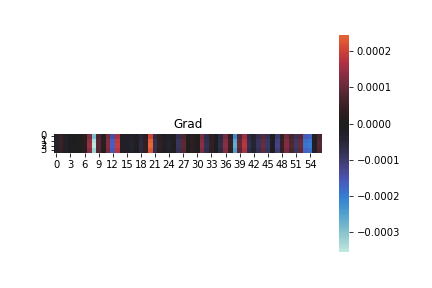

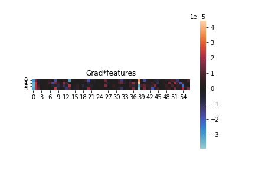

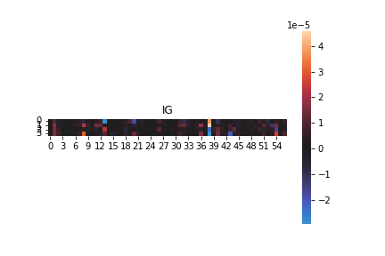

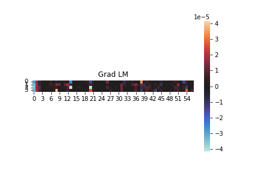

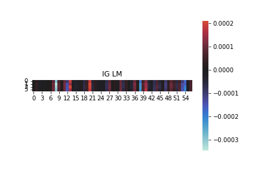

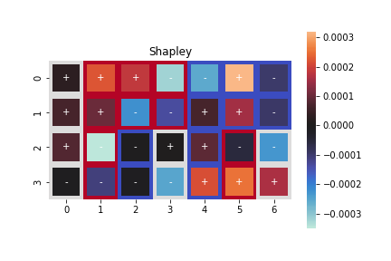

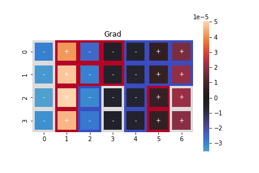

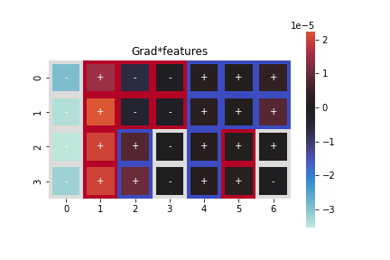

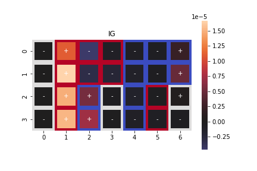

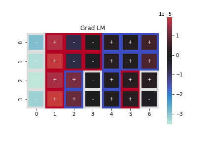

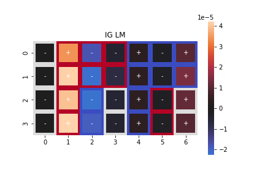

### Simulation 9

- 6 covariables ont un effet qui dépend d’un groupe (positif/négatif/nul)
- 6 covariables sans effet
- 4 groupes avec des effets différents
- les 4 groupes sont mis en covariables

```
## [1] "AUC sessions-insectes sans covariables : 0.84"
```

```
## [1] "AUC sessions-insectes avec covariables : 0.841"
```

```
## [1] "AUC plantes-insectes sans covariables : 0.665"
```

```
## [1] "AUC plantes-insectes avec covariables : 0.668"
```

|  | Shapley | GRAD | GRADxInput | IG | GRAD_LM | IG1_LM |
| --- | --- | --- | --- | --- | --- | --- |
| + | 0.46 | 0.85 | 0.85 | 0.84 | 0.85 | 0.83 |
| - | 0.53 | 0.53 | 0.14 | 0.12 | 0.14 | 0.54 |
| AUC | 0.49 | 0.46 | 0.88 | 0.87 | 0.92 | 0.48 |

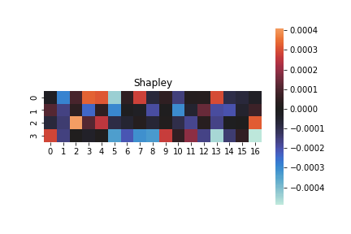

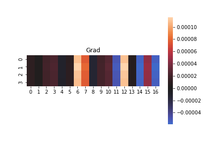

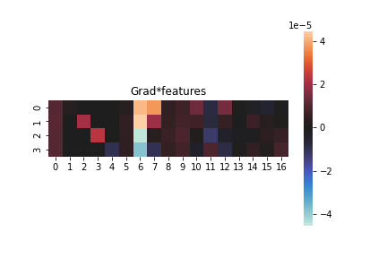

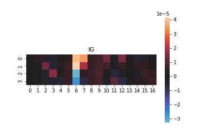

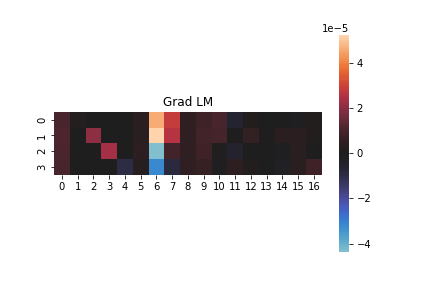

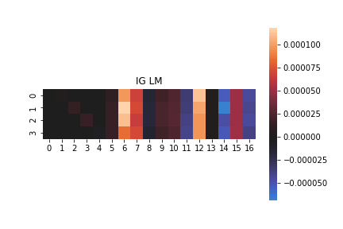

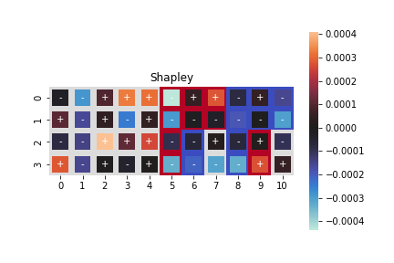

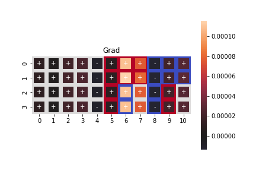

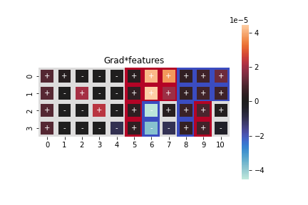

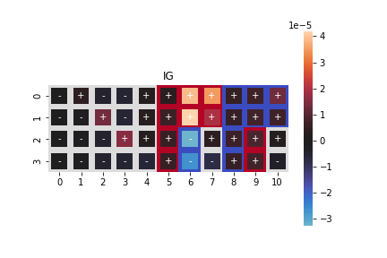

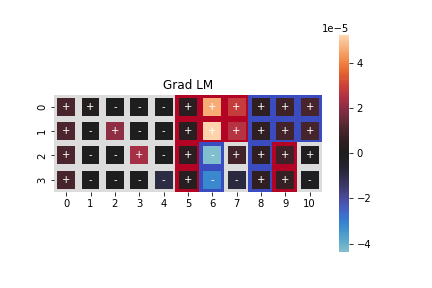

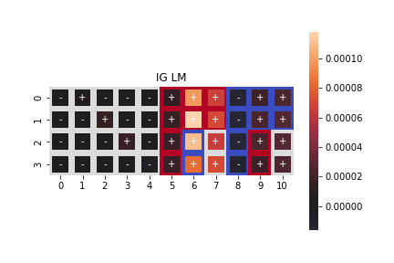

### Simulation 10

- 3 covariables ont un effet positif
- 3 covariables ont un effet négatif
- 1 covariable sans effet
- la premiere covariable avec effet positif et celle avec effet négatif sont mises avec le HSIC

l’objectif est de voir si les scores attribués aux variables avec le HSIC sont plus petits que les autres.

```
## [1] "AUC sessions-insectes sans covariables : 0.884"
```

```
## [1] "AUC sessions-insectes avec covariables : 0.884"
```

```
## [1] "AUC plantes-insectes sans covariables : 0.834"
```

```
## [1] "AUC plantes-insectes avec covariables : 0.834"
```

|  | Shapley | GRAD | GRADxInput | IG | GRAD_LM | IG1_LM |
| --- | --- | --- | --- | --- | --- | --- |
| + | 0.92 | 0.93 | 0.93 | 0.92 | 0.93 | 0.92 |
| - | 0.05 | 0.95 | 0.05 | 0.07 | 0.05 | 0.93 |
| AUC | 0.75 | 0.41 | 0.75 | 0.76 | 0.77 | 0.39 |

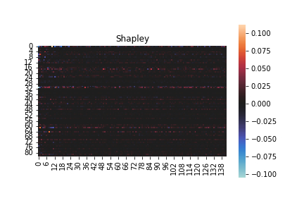

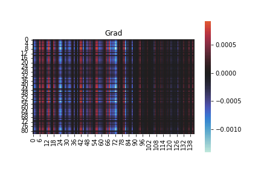

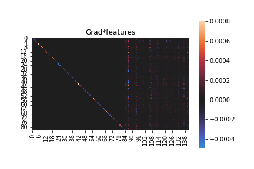

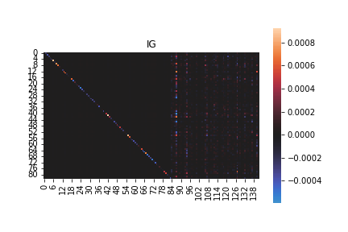

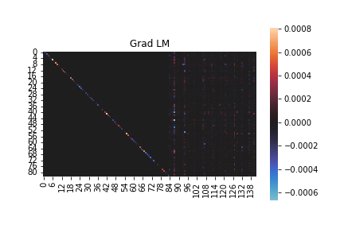

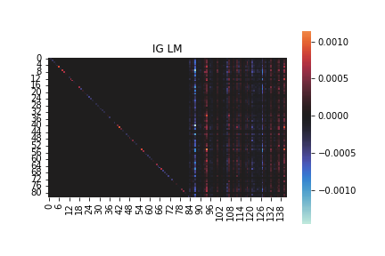

### Simulation 11

- 8 variables ont un effet positif ou négatif en fonction du groupe auquel il appartient
- 50 variables sont sans effet
- la premiere covariable avec effet positif et celle avec effet négatif sont mises avec le HSIC

l’objectif est de voir si les scores attribués aux variables avec le HSIC sont plus petits que les autres.

```
## [1] "AUC sessions-insectes sans covariables : 0.849"
```

```
## [1] "AUC sessions-insectes avec covariables : 0.822"
```

```
## [1] "AUC plantes-insectes sans covariables : 0.729"
```

```
## [1] "AUC plantes-insectes avec covariables : 0.725"
```

|  | Shapley | GRAD | GRADxInput | IG | GRAD_LM | IG1_LM |
| --- | --- | --- | --- | --- | --- | --- |
| + | 0.52 | 0.67 | 0.67 | 0.68 | 0.67 | 0.68 |
| - | 0.48 | 0.65 | 0.35 | 0.38 | 0.35 | 0.61 |
| AUC | 0.49 | 0.45 | 0.85 | 0.87 | 0.88 | 0.46 |

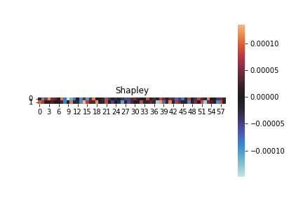

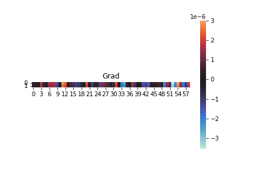

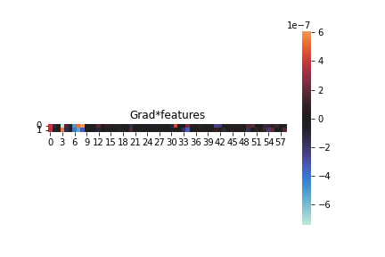

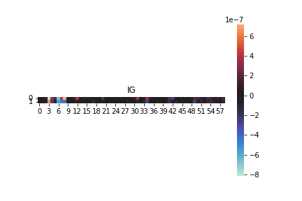

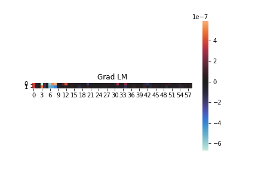

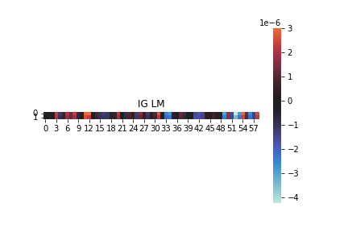

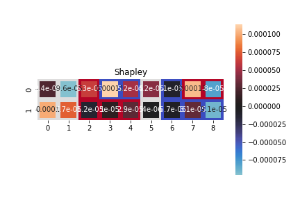

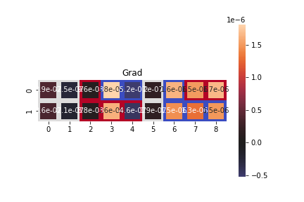

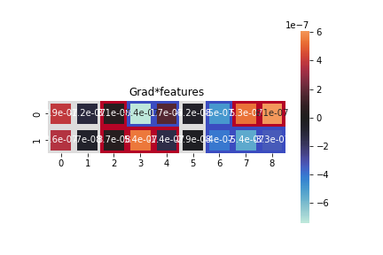

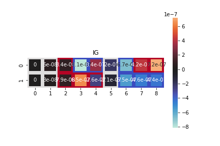

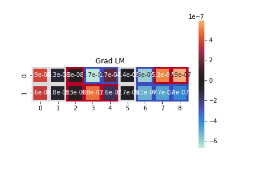